# Numerical Taxonomy and Ordination

### 3.5.3 How Many Clusters?

There is no simple answer to the question “How many clusters are in my data?” Some metrics, however, can be used to help estimate a “reasonable” number of clusters. The mean silhouette width is a useful index of “cluster compactness” relative to neighbor clusters (Rousseeuw 1987). Larger silhouette widths suggest tighter grouping.

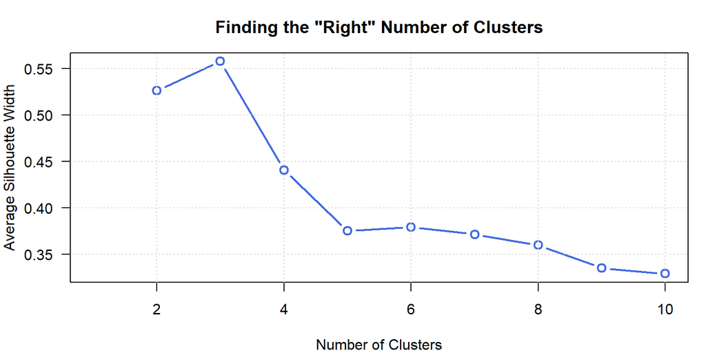

```r
# re-make data, this time with all profiles
data('sp4', package = 'aqp')
sp4.std <- data.frame(sp4[, c('id', 'name', 'top', 'bottom')], scale( sp4[, c('Mg', 'Ca')]))

# perform hard clustering
sil.widths <- vector(mode='numeric')
for(i in 2:10) {
  cl <- pam(sp4.std[, c('Mg', 'Ca')], k = i, stand = FALSE)
  sil.widths[i] <- cl$silinfo$avg.width
}

par(mar=c(4,4,3,1))
plot(sil.widths, type='b', xlab='Number of Clusters', ylab='Average Silhouette Width', las=1, lwd=2, col='RoyalBlue', cex=1.25, main='Finding the "Right" Number of Clusters')
grid()
```

According to *this metric*, it looks like 3 clusters is reasonable. Again, this is a judgement call–most decisions related to clustering algorithm selection and the “optimal number of clusters” are somewhat subjective.

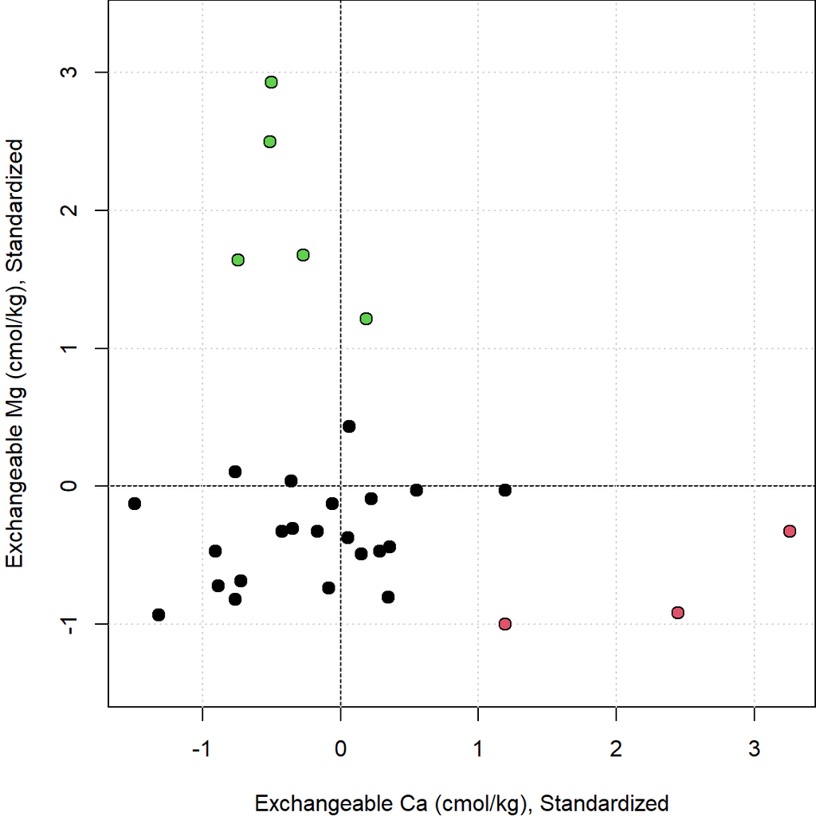

```r
# perform fuzzy clustering
cl <- pam(sp4.std[, c('Mg', 'Ca')], k = 3, stand = FALSE)

# setup plot
par(mar=c(4,4,0,0))
plot(sp4.std$Mg, sp4.std$Ca, asp=1, ylab='Exchangeable Mg (cmol/kg), Standardized', xlab='Exchangeable Ca (cmol/kg), Standardized', type='n')
abline(h=0, v=0, col='black')
grid()

# add original obs
points(sp4.std$Mg, sp4.std$Ca, bg=cl$clustering, col='black', cex=1.25, pch=21)
```

## 3.6 Ordination

### 3.6.1 Principal Component Analysis

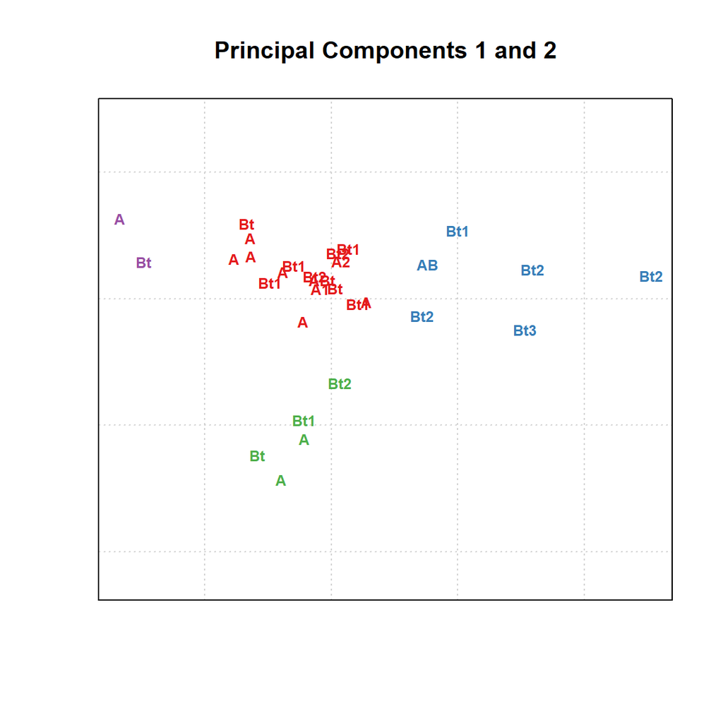

```r
# re-make data, this time with all profiles
data('sp4', package = 'aqp')
sp4 <- sp4[, c('name', 'clay', 'sand', 'Mg', 'Ca', 'CEC_7')]
sp4.scaled <- data.frame(name=sp4[, 1], round(scale( sp4[, -1]), 2))

# PCA
# note that we are leaving out the first column: the horizon names
# note the syntax used to extract the principal components
# note that PCA doesn't use the distance matrix
pca <- predict(princomp(sp4.scaled[, -1]))

## perform clustering to highlight structure in the PCA
# distance matrix
d <- dist(sp4.scaled[, -1])
m <- as.matrix(d)
dimnames(m) <- list(sp4.scaled$name, sp4.scaled$name)
d <- as.dist(m)
# dendrogram from divisive clustering
dd <- diana(d)
h <- as.hclust(dd)
p <- as.phylo(h)

# define colors based on cutting a divisive hierarchical clustering into 4 groups
cols <- brewer.pal(9, 'Set1')[cutree(h, 4)]

# plot first 2 PC
plot(pca[, 1:2], asp=1, type='n', axes=FALSE, xlab='', ylab='', main="Principal Components 1 and 2")
grid()
text(pca[, 1:2], sp4.scaled$name, cex=0.75, col=cols, font=2)
box()
```

### 3.6.2 Sammon’s Non-linear Mapping

Simple interface to nMDS, input is a distance matrix. Note that this algorithm will fail if there are 0’s or ties within the distance matrix. See `?sammon` for details.

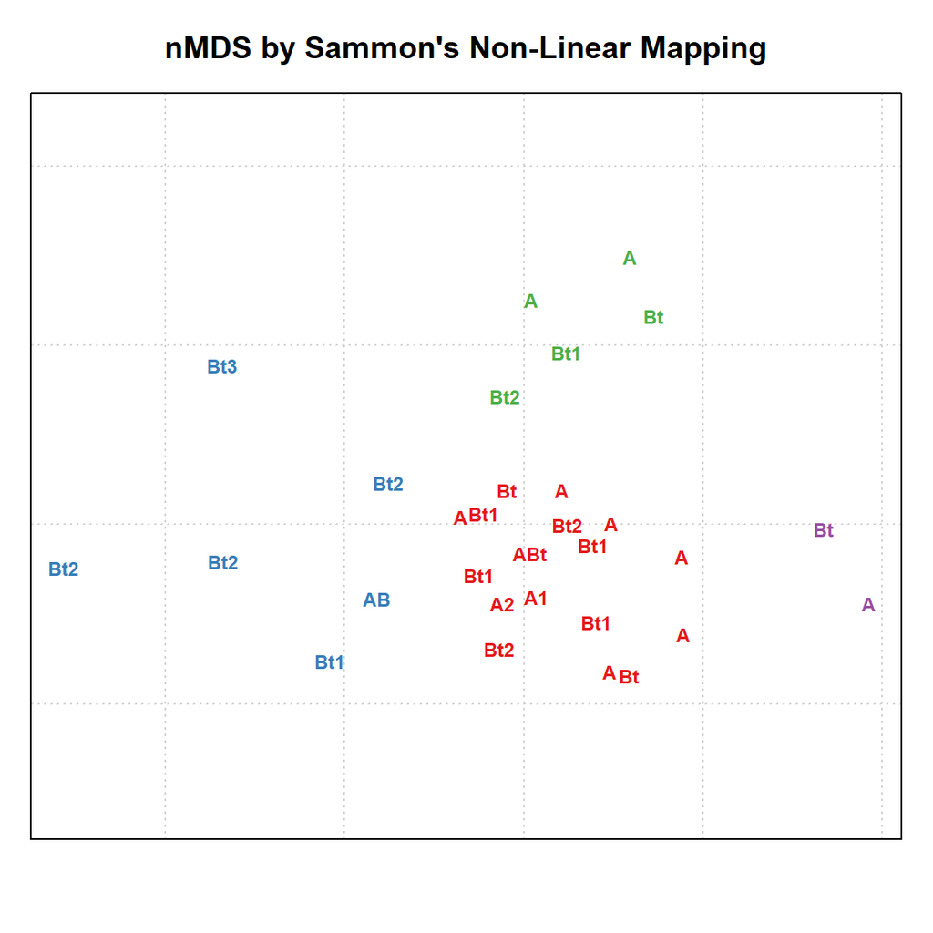

```r
# re-make data, this time with all profiles
data('sp4', package = 'aqp')
sp4 <- sp4[, c('name', 'clay', 'sand', 'Mg', 'Ca', 'CEC_7')]
sp4.scaled <- data.frame(name=sp4[, 1], round(scale( sp4[, -1]), 2))

# distance matrix
d <- dist(sp4.scaled[, -1])
m <- as.matrix(d)
dimnames(m) <- list(sp4.scaled$name, sp4.scaled$name)
d <- as.dist(m)
# dendrogram from divisive clustering
dd <- diana(d)
h <- as.hclust(dd)
p <- as.phylo(h)

# define colors based on cutting a divisive hierarchical clustering into 4 groups
cols <- brewer.pal(9, 'Set1')[cutree(h, 4)]

# nMDS from distance matrix
s <- sammon(d)

# plot
par(mar=c(3,1,3,1))
plot(s$points, asp=1, type='n', axes=FALSE, xlab='', ylab='', main="nMDS by Sammon's Non-Linear Mapping")
# abline(v=0, h=0, col='black')
grid()
text(s$points, rownames(s$points), cex=0.75, col=cols, font=2)
box()
```

### 3.6.3 nMDS with the `vegan` Package

The following example is quite brief. See the [*Introduction to ordination in vegan*](https://cran.r-project.org/web/packages/vegan/vignettes/intro-vegan.pdf) vignette for some excellent worked examples and ecological interpretation. The [vegan package FAQ](https://cran.r-project.org/web/packages/vegan/vignettes/FAQ-vegan.html) is another excellent resource. [*Numerical Ecology with R*](http://www.springer.com/us/book/9781441979759) can be used as both reference and learning resource.

The `metaMDS()` function from the `vegan` package provides a convenience function that automates most of the steps required to create an oridination.

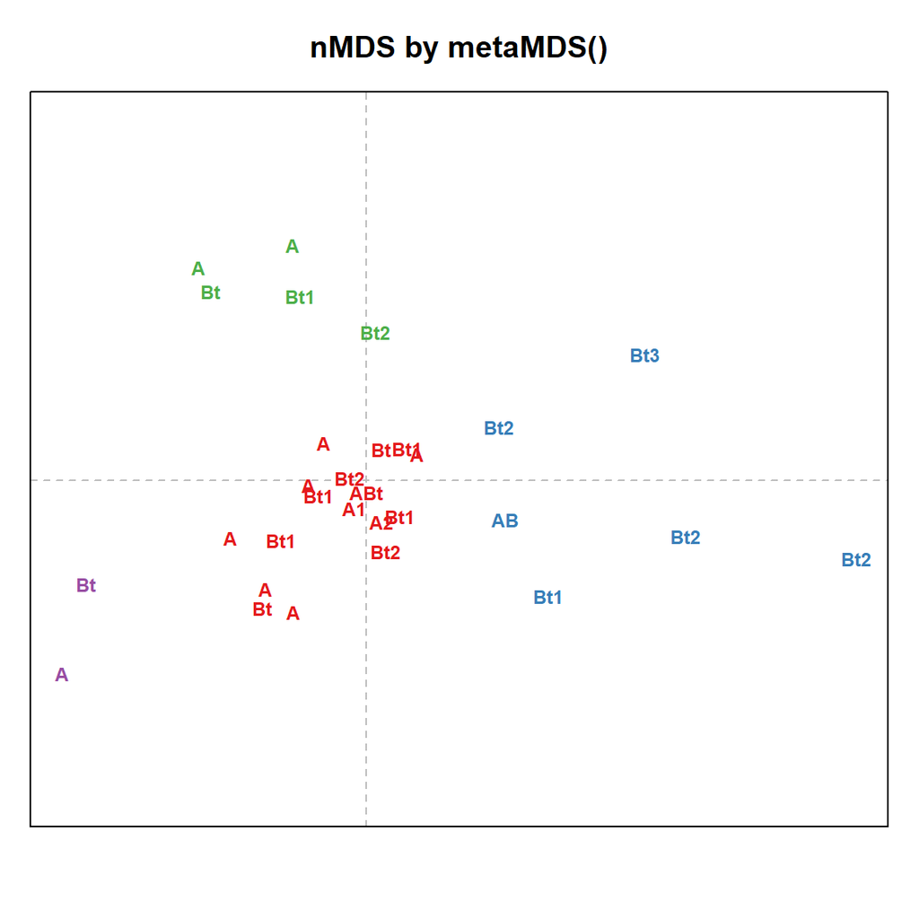

```r
# re-make data, this time with all profiles
data('sp4', package = 'aqp')
sp4 <- sp4[, c('name', 'clay', 'sand', 'Mg', 'Ca', 'CEC_7')]
sp4.scaled <- data.frame(name=sp4[, 1], round(scale( sp4[, -1]), 2))

# define colors based on natural groupings
cols <- brewer.pal(9, 'Set1')

# distance calc + ordination
s <- metaMDS(sp4.scaled[, -1], distance = 'gower', autotransform = FALSE, wascores=FALSE)

## this is used to generate 4 classes from a divisive hierarchical clustering
# manually compute distance matrix
d <- dist(sp4.scaled[, -1])
m <- as.matrix(d)
dimnames(m) <- list(sp4.scaled$name, sp4.scaled$name)
d <- as.dist(m)
# dendrogram from divisive clustering
dd <- diana(d)
h <- as.hclust(dd)

# define colors based on cutting a divisive hierarchical clustering into 4 groups
cols <- brewer.pal(9, 'Set1')[cutree(h, 4)]

# plot ordination
par(mar=c(3,1,3,1))
fig <- ordiplot(s, type='none', cex.axis=0.75, axes=FALSE, xlab='', ylab='', main='nMDS by metaMDS()')
abline(h=0, v=0, lty=2, col='grey')
text(fig$sites, sp4$name, cex=0.75, font=2, col=cols)
# ordicluster(fig, agnes(daisy(sp4.scaled[, -1]), method='ward'), prune=3, col = "orange")
box()
```

### 3.6.4 Rotations

procrustes, etc.

```r
# https://ncss-tech.github.io/AQP/aqp/color-contrast.html
```

# 4 Practical Applications

Before you work through the following examples, you should review the [SoilProfileCollection object tutorial](http://ncss-tech.github.io/AQP/aqp/aqp-intro.html).

## 4.1 Pair-Wise Distances Between Soil Profiles

```r
# init example data
data(sp4)
depths(sp4) <- id ~ top + bottom

# eval dissimilarity:
# using Ex-Ca:Mg and CEC at pH 7
# with no depth-weighting (k=0)
# to a maximum depth of 40 cm
d <- profile_compare(sp4, vars=c('ex_Ca_to_Mg', 'CEC_7'), k=0, max_d=40)

# check distance matrix:
round(d, 1)
```

```
## Dissimilarities :
##                colusa glenn kings mariposa mendocino napa san benito shasta shasta-trinity
## glenn            13.5
## kings            16.0  12.7
## mariposa          8.4  11.3  16.5
## mendocino        11.5   8.0  16.4     15.0
## napa             30.4  24.1  29.4     29.2      21.6
## san benito       25.7  20.6  26.3     28.2      15.8 18.0
## shasta           17.2  13.3   8.7     17.6      17.1 33.7       22.2
## shasta-trinity    6.4  16.6  22.3      9.6      16.5 29.8       27.2   23.3
## tehama           28.7  22.9  27.9     27.3      20.0  8.8       15.1   31.4           27.9
##
## Metric :  mixed ;  Types = I, I
## Number of objects : 10
```

```r
# cluster via divisive method
clust <- diana(d)
```

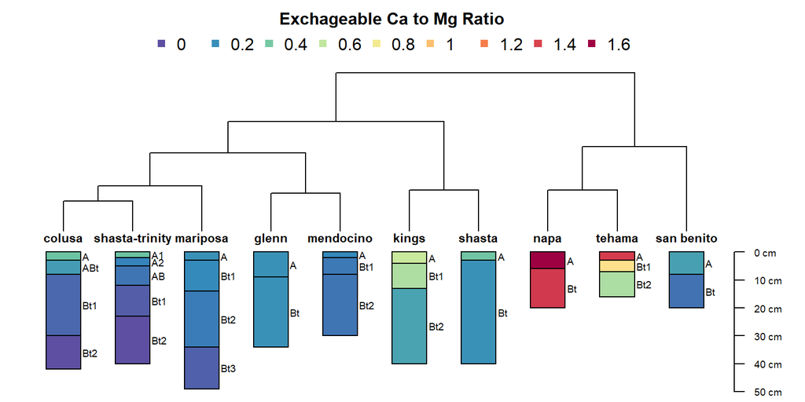

```r
# vizualize dissimilarity matrix via hierarchical clustering
par(mar=c(0,0,3,1))
plotProfileDendrogram(sp4, clust, dend.y.scale = max(d), scaling.factor = (1/max(d) * 10), y.offset = 2.25, width=0.25, cex.names=0.6, color='ex_Ca_to_Mg', col.label='Exchageable Ca to Mg Ratio')
```

## 4.2 Pair-Wise Distances Between Soil Series

The following figures are a preview of some new [functionality planned for SoilWeb/SDE](http://soilmap2-1.lawr.ucdavis.edu/mike/soilweb/sde/?series=drummer). These related tutorials cover similar material in greater detail:

- [Competing Soil Series](https://ncss-tech.github.io/AQP/soilDB/competing-series.html)
- [Querying Soil Series Data](https://ncss-tech.github.io/AQP/soilDB/soil-series-query-functions.html)

The `fetchOSD` function can return [additional summaries](https://ncss-tech.github.io/AQP/soilDB/soil-series-query-functions.html) tabulated from climate data, MLRA boundaries, SSURGO, and much more with the `extended=TRUE` argument. Lets experiment with distances computed from annual climate data and hillslope position.

```r
# soil series from around CONUS
soils <- c('redding', 'pentz', 'willows', 'yolo', 'hanford', 'cecil', 'sycamore', 'KLAMATH', 'drummer', 'musick', 'zook')
s <- fetchOSD(soils, extended = TRUE)

# note additional data, packed into a list
str(s, 1)
```

```
## List of 14
##  $ SPC             :Formal class 'SoilProfileCollection' [package "aqp"] with 9 slots
##  $ competing       :'data.frame':    57 obs. of  3 variables:
##  $ geog_assoc_soils:'data.frame':    75 obs. of  2 variables:
##  $ geomcomp        :'data.frame':    9 obs. of  9 variables:
##  $ hillpos         :'data.frame':    10 obs. of  8 variables:
##  $ mtnpos          :'data.frame':    2 obs. of  9 variables:
##  $ terrace         :'data.frame':    8 obs. of  5 variables:
##  $ flats           :'data.frame':    7 obs. of  7 variables:
##  $ pmkind          :'data.frame':    19 obs. of  5 variables:
##  $ pmorigin        :'data.frame':    44 obs. of  5 variables:
##  $ mlra            :'data.frame':    75 obs. of  4 variables:
##  $ climate.annual  :'data.frame':    88 obs. of  12 variables:
##  $ climate.monthly :'data.frame':    264 obs. of  14 variables:
##  $ soilweb.metadata:'data.frame':    17 obs. of  2 variables:
```

### 4.2.1 Annual Climate Data

The [`vizAnnualClimate` function (sharpshootR package)](http://ncss-tech.github.io/sharpshootR/docs/reference/vizAnnualClimate.html) arranges percentiles of annual climate summaries according to divisive hierarchical clustering applied to median values. Climate summaries were derived from 800m, daily PRISM data spanning 1981-2010.

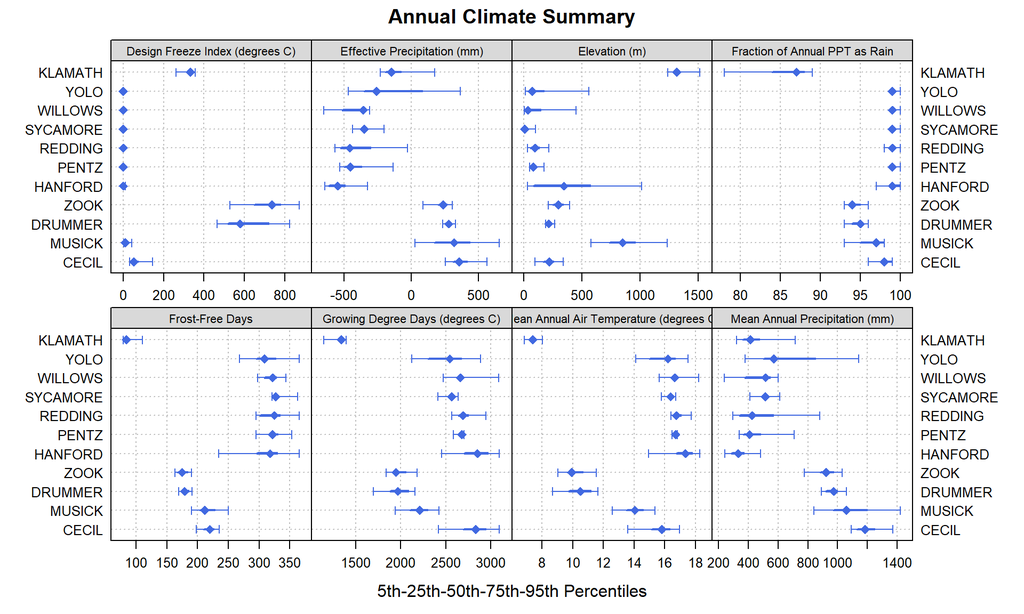

```r
# control color like this
trellis.par.set(plot.line=list(col='RoyalBlue'))

# control centers symbol and size here
res <- vizAnnualClimate(s$climate.annual, IQR.cex = 1.25, cex=1.1, pch=18)

# plot figure, this is Lattice graphics
print(res$fig)
```

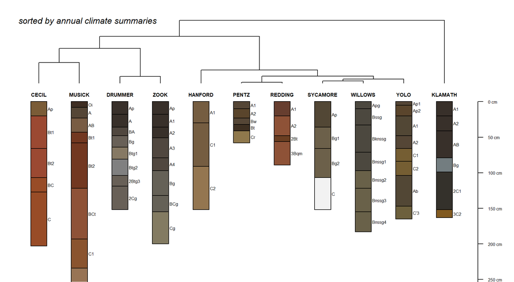

```r
# do something with clustering
par(mar=c(0,0,1,1))
# usually requires tinkering...
plotProfileDendrogram(s$SPC, clust = res$clust, scaling.factor = 0.05, width = 0.2, y.offset = 1.3)
mtext('sorted by annual climate summaries', side = 3, at = 0.5, adj = 0, line = -1.5, font=3)
```

### 4.2.2 Hillslope Position

The [`vizHillslopePosition` function (sharpshootR package)](http://ncss-tech.github.io/sharpshootR/docs/reference/vizHillslopePosition.html) arranges hillslope position proportions (SSURGO) according to divisive hierarchical clustering. Proportions are used as characteristics for each soil series. The branches of the dendrogram are rotated so that ordering within the figure approximates the hydrologic gradient as closely as possible. Rotation is performed by the `dendextend::rotate` function.

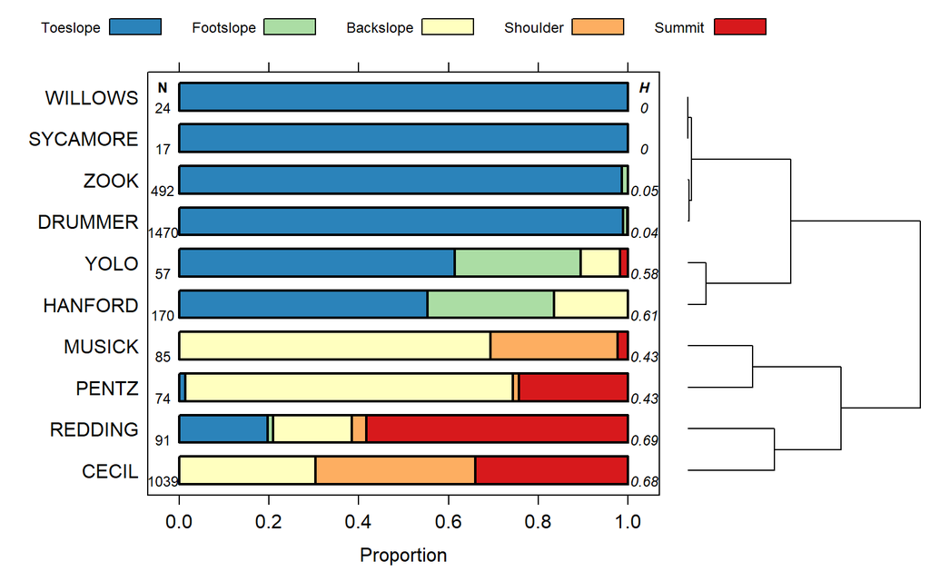

```r
# result is a lattice graphics object
res <- vizHillslopePosition(s$hillpos)
print(res$fig)
```

## 4.3 Pair-Wise Distances Between Subgroup-Level Taxa

The following are demonstrations of pair-wise distances computed from categorical data and the use of a dendrogram to organize groups from Soil Taxonomy. [Click here](http://ncss-tech.github.io/AQP/sharpshootR/OSD-dendrogram.html) for details.

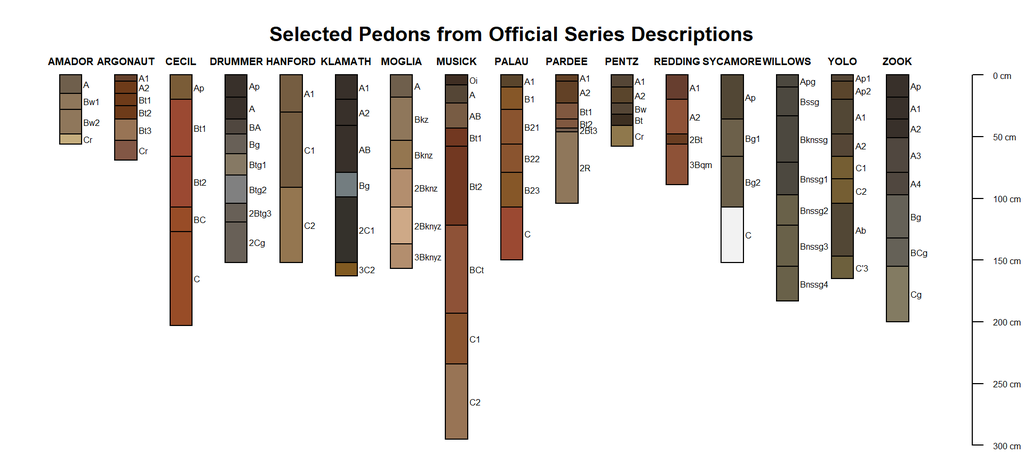

```r
# define a vector of series
s.list <- c('amador', 'redding', 'pentz', 'willows', 'pardee', 'yolo', 'hanford', 'cecil', 'sycamore', 'KLAMATH', 'MOGLIA', 'drummer', 'musick', 'zook', 'argonaut', 'PALAU')

# get and SPC object with basic data on these series
s <- fetchOSD(s.list)

# graphical check
par(mar=c(0,0,2,0))
plot(s) ; title('Selected Pedons from Official Series Descriptions', line=0)
```

```r
# check structure of some site-level attributes
# head(site(s))[, c('id', 'soilorder', 'suborder', 'greatgroup', 'subgroup')])
```

| id | soilorder | suborder | greatgroup | subgroup |
| --- | --- | --- | --- | --- |
| AMADOR | inceptisols | xerepts | haploxerepts | typic haploxerepts |
| ARGONAUT | alfisols | xeralfs | haploxeralfs | mollic haploxeralfs |
| CECIL | ultisols | udults | kanhapludults | typic kanhapludults |
| DRUMMER | mollisols | aquolls | endoaquolls | typic endoaquolls |
| HANFORD | entisols | orthents | xerorthents | typic xerorthents |
| KLAMATH | mollisols | aquolls | cryaquolls | cumulic cryaquolls |

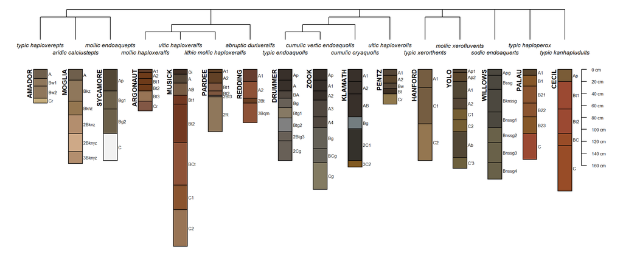

```r
par(mar=c(0,1,1,1))
# plot dendrogram + profiles
d <- SoilTaxonomyDendrogram(s, scaling.factor = 0.01, width=0.2, cex.names=0.5)
```

Check the resulting distance matrix.

```r
print(d)
```

[output not shown]

## 4.4 Soil Color Signatures

See this [related tutorial](http://ncss-tech.github.io/AQP/aqp/soil-color-signatures.html) for additional examples.

```r
# manually convert Munsell -> sRGB
rgb.data <- munsell2rgb(s$hue, s$value, s$chroma, return_triplets = TRUE)
s$r <- rgb.data$r
s$g <- rgb.data$g
s$b <- rgb.data$b

# eval color signature
pig <- soilColorSignature(s, RescaleLightnessBy = 5, method='depthSlices')

# display results as table
kable_styling(knitr::kable(head(pig), digits = 3, row.names = FALSE))
```

| id | A.0.1 | A.0.5 | A.0.9 | B.0.1 | B.0.5 | B.0.9 | L.0.1 | L.0.5 | L.0.9 |
| --- | --- | --- | --- | --- | --- | --- | --- | --- | --- |
| AMADOR | 3.681 | 4.870 | 1.919 | 13.298 | 18.956 | 27.828 | 8.250 | 10.324 | 14.333 |
| ARGONAUT | 13.549 | 19.311 | 15.876 | 19.548 | 30.215 | 17.613 | 6.159 | 6.161 | 8.250 |
| CECIL | 7.378 | 32.895 | 28.722 | 25.999 | 29.497 | 35.807 | 8.254 | 8.251 | 8.254 |
| DRUMMER | 2.189 | 1.478 | 1.478 | 5.367 | 6.176 | 6.176 | 4.111 | 8.247 | 8.247 |
| HANFORD | 5.629 | 5.629 | 6.611 | 19.847 | 19.847 | 25.480 | 8.252 | 8.252 | 10.327 |
| KLAMATH | 2.189 | 2.189 | 10.371 | 5.367 | 5.367 | 37.715 | 4.111 | 4.111 | 8.257 |

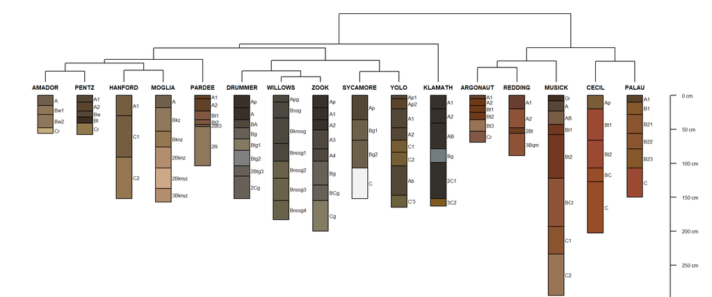

```r
# move row names over for distance matrix
row.names(pig) <- pig[, 1]
d <- daisy(pig[, -1])
dd <- diana(d)

# plot
par(mar=c(0,0,0.25,1))
plotProfileDendrogram(s, dd, dend.y.scale = max(d) * 2, scaling.factor = 0.3, y.offset = 6, width=0.2, cex.names=0.5)
```

## 4.5 Clustering of Soil Colors

Just for fun, use hierarchical clustering and nMDS on soil color data from the OSDs that were used in the previous example.

```r
# extract horizon data from select OSDs in above example
h <- horizons(s)

# convert Munsell color notation to sRGB
# these are moist colors
rgb.data <- munsell2rgb(h$hue, h$value, h$chroma, return_triplets = TRUE)
lab.data <- munsell2rgb(h$hue, h$value, h$chroma, returnLAB = TRUE)

# check
head(rgb.data)
```

```
##           r         g          b
## 1 0.4360624 0.3706674 0.29697452
## 2 0.5589675 0.4673350 0.35663875
## 3 0.5589675 0.4673350 0.35663875
## 4 0.7719679 0.6774631 0.48997537
## 5 0.3940324 0.2499977 0.16682669
## 6 0.4309729 0.2327690 0.09771028
```

```r
head(lab.data)
```

```
##          L         A        B
## 1 41.24855  3.681301 13.29762
## 2 51.62124  4.870262 18.95563
## 3 51.62124  4.870262 18.95563
## 4 71.66388  1.919454 27.82850
## 5 30.79580 13.548688 19.54789
## 6 30.80674 19.311423 30.21539
```

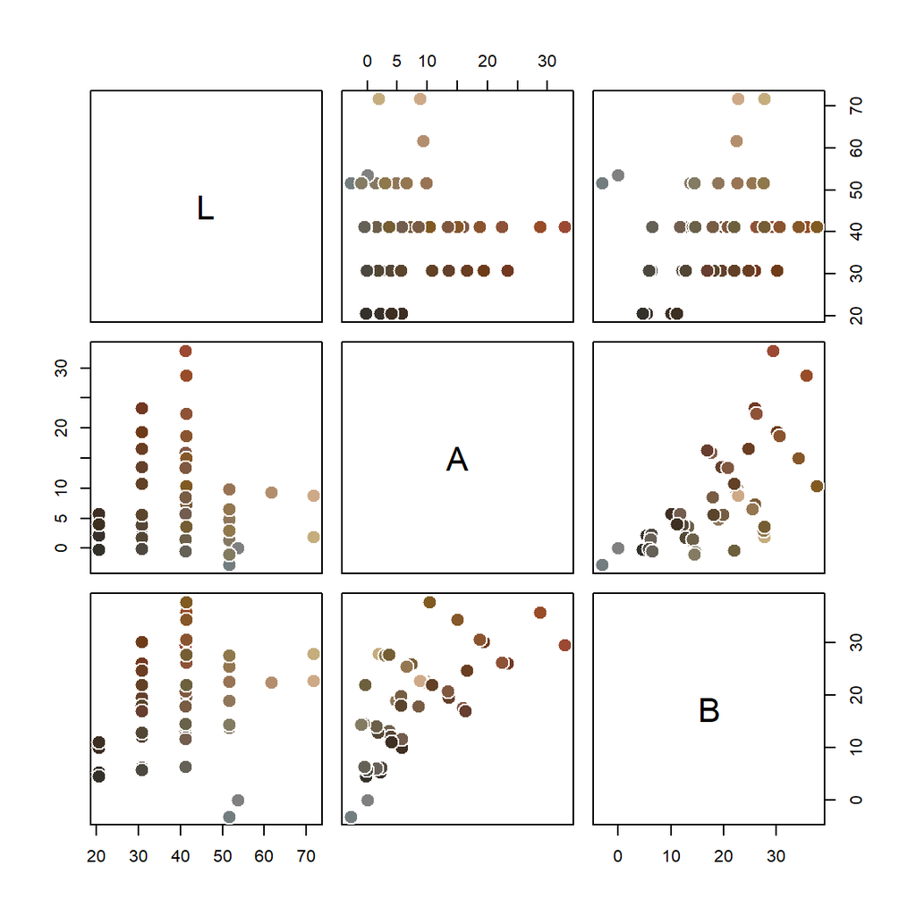

```r
# remove NA
rgb.data <- na.omit(rgb.data)
lab.data <- na.omit(lab.data)

# retain unique colors
rgb.data <- unique(rgb.data)
lab.data <- unique(lab.data)

# visualize colors in LAB coordinates
pairs(lab.data, col='white', bg=rgb(rgb.data), pch=21, cex=2)
```

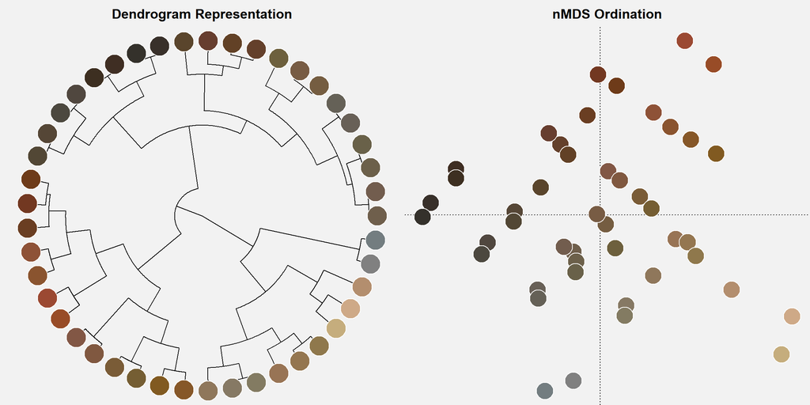

```r
# create distance matrix from LAB coordinates
d <- daisy(lab.data, stand=FALSE)

# divisive heirarcical clustering
d.hclust <- as.hclust(diana(d))

# convert to phylo class for nicer plotting
p <- as.phylo(d.hclust)

# perform nMDS on distance matrix
d.sammon <- sammon(d)

# setup multi-figure page
par(mfcol=c(1,2), mar=c(0,0,2,0), bg=grey(0.95))

# plot fan-style dendrogram
plot(p, font=2, cex=0.5, type='fan', show.tip.label=FALSE, main='Dendrogram Representation')
# add colors at dendrogram tips
tiplabels(pch=21, cex=4, col='white', bg=rgb(rgb.data))

# plot nMDS ordination
plot(d.sammon$points, type='n', axes=FALSE, xlab='', ylab='', asp=1, main='nMDS Ordination')
abline(h=0, v=0, col='black', lty=3)
points(d.sammon$points, bg=rgb(rgb.data), pch=21, cex=3.5, col='white')
```

## 4.6 *“How Do the Interpretations Compare?”*

Example borrowed from [this tutorial](http://ncss-tech.github.io/AQP/soilDB/SDA-cointerp-tutorial.html).

```r
library(reshape2)
# set list of component names, same as soil color example
s.list <- c('amador', 'redding', 'pentz', 'willows', 'pardee', 'yolo',
            'hanford', 'cecil', 'sycamore', 'KLAMATH', 'MOGLIA', 'drummer',
            'musick', 'zook', 'argonaut', 'PALAU')

# set list of relevant interpretations
interp.list <- c('ENG - Construction Materials; Topsoil',
'ENG - Sewage Lagoons', 'ENG - Septic Tank Absorption Fields',
'ENG - Unpaved Local Roads and Streets')

# compose query
q <- paste0("SELECT UPPER(compname) as compname, mrulename, AVG(interplr) as interplr_mean
FROM component INNER JOIN cointerp ON component.cokey = cointerp.cokey
WHERE compname IN ", format_SQL_in_statement(s.list), "
AND seqnum = 0
AND mrulename IN ", format_SQL_in_statement(interp.list), "
AND interplr IS NOT NULL
GROUP BY compname, mrulename;")

# send query
x <- SDA_query(q)

# reshape long -> wide
x.wide <- dcast(x, compname ~ mrulename, value.var = 'interplr_mean')
knitr::kable(x.wide, digits = 3, caption="Mean Fuzzy Ratings for Select Soil Series")
```

Mean Fuzzy Ratings for Select Soil Series

| compname | ENG - Construction Materials; Topsoil | ENG - Septic Tank Absorption Fields | ENG - Sewage Lagoons | ENG - Unpaved Local Roads and Streets |
| --- | --- | --- | --- | --- |
| AMADOR | 0.000 | 1.000 | 1.000 | 0.691 |
| ARGONAUT | 0.050 | 1.000 | 1.000 | 1.000 |
| CECIL | 0.414 | 0.666 | 0.854 | 0.302 |
| DRUMMER | 0.000 | 1.000 | 1.000 | 1.000 |
| HANFORD | 0.678 | 0.989 | 1.000 | 0.220 |
| KLAMATH | 0.000 | 1.000 | 1.000 | 1.000 |
| MOGLIA | 0.000 | 1.000 | 0.500 | 1.000 |
| MUSICK | 0.245 | 1.000 | 0.963 | 0.832 |
| PALAU | 0.011 | 1.000 | 0.864 | 1.000 |
| PARDEE | 0.000 | 1.000 | 1.000 | 1.000 |
| PENTZ | 0.003 | 1.000 | 1.000 | 0.714 |
| REDDING | 0.022 | 1.000 | 1.000 | 0.907 |
| SYCAMORE | 0.824 | 0.998 | 0.756 | 0.919 |
| WILLOWS | 0.000 | 1.000 | 0.947 | 1.000 |
| YOLO | 0.843 | 0.914 | 0.608 | 0.769 |
| ZOOK | 0.004 | 1.000 | 1.000 | 1.000 |

```r
# note: component name and series name have been converted to upper case
# sort rows of fuzzy ratings based on profiles from OSDs
new.order <- match(x.wide$compname, profile_id(s))
x.wide <- x.wide[new.order, ]

# copy ids to row.names so that they are preserved in distance matrix
row.names(x.wide) <- x.wide$compname

# create distance matrix
d <- daisy(x.wide[, -1])

# divisive hierarchical clustering
clust <- diana(d)
```

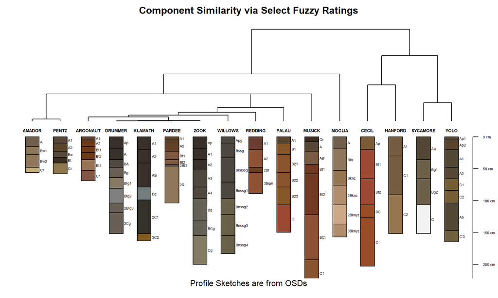

```r
par(mar=c(2,0,2,0))
plotProfileDendrogram(s, clust, dend.y.scale = 1.5, scaling.factor = 0.004, y.offset = 0.1, width=0.25, cex.names=0.45)
title('Component Similarity via Select Fuzzy Ratings')
mtext('Profile Sketches are from OSDs', 1)
```

## 4.7 MLRA Concepts via Climate and Elevation Samples

Get and process example data, originally sampled from PRISM raster and DEM within MLRA 15, 18, 22A, and 22B. Variables include:

- elevation
- mean annual air temperature
- mean annuap precipitation
- fraction of annual precipitation as rain
- effective precipitation
- frost-free days
- growing degree days

```r
library(MASS)
library(vegan)
library(cluster)
library(RColorBrewer)

# get example data
# init a temp file
tf <- tempfile()

# download compressed CSV to temp file
download.file('https://github.com/ncss-tech/stats_for_soil_survey/raw/master/data/clustering_and_ordination/MLRA-raster-data-example.csv.gz', destfile = tf, quiet = TRUE)
# read-in from compressed CSV to data.frame object
d.sub <- read.csv(gzfile(tf), stringsAsFactors = FALSE)

# check: note that the column names are quite strange
head(d.sub)

# set factor levels
mu.set <- c('15', '18', '22A', '22B')
d.sub$.id <- factor(d.sub$.id, levels = mu.set)

# define some nice colors
cols <- brewer.pal(9, 'Set1')
# remove light colors
cols <- cols[c(1:5,7,9)]
```

### 4.7.1 Nonmetric Multidimensional Scaling

A smooh surface fit to mean annual air temperature highlights structure within a nMDS ordination.

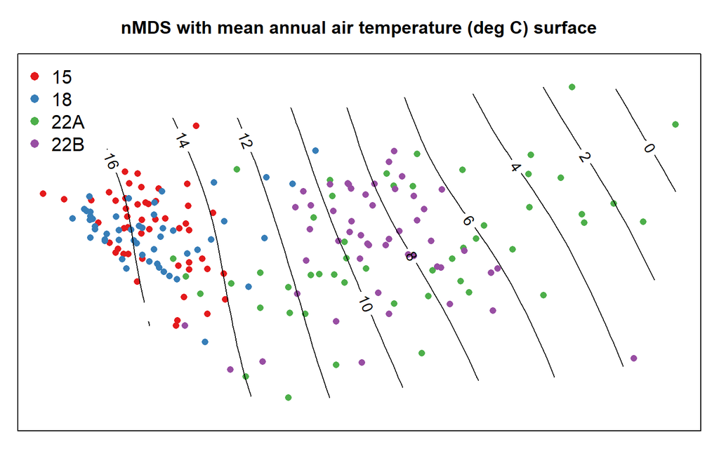

```r
m <- metaMDS(d.sub[, -c(1:3)], distance = 'gower')

# margins
par(mar=c(1,1,3,1))

# setup plot
o <- ordiplot(m, type='n', axes=FALSE)
# add points, colored accoring to MLRA
points(o, 'sites', cex=1, col=cols[as.numeric(d.sub$.id)], pch=16)

# overlay smooth surface of variable used in ordination
ordisurf(m, d.sub$Mean.Annual.Air.Temperature..degrees.C., add=TRUE, col='black', labcex=1)
legend('topleft', legend=mu.set, pch=16, col=cols, bty='n', cex=1.25)

title('nMDS with mean annual air temperature (deg C) surface')

box()
```

### 4.7.2 Principle Coordinates

This example generates an ordination (via principal coordinates) of environmental variables (PRSIM and elevation) associated with MLRAs 15, 18, 22A, and 22B. Ellipses represent 50% probability contours via *multivariate homogeneity of group dispersions*. See comments in the code for details. Note that this example was [extracted from the Region 2 Map Unit Comparison Report](https://github.com/ncss-tech/soilReports/tree/master/inst/reports/region2/mu-comparison).

**Thoughts on interpretation:**

- The relative position of points and ellipses are meaningful; absolute position will vary each time the figure is generated.
- Look for “diffuse” vs. “concentrated” clusters: these suggest relatively broadly vs. narrowly defined concepts.
- Nesting of clusters (e.g. smaller cluster contained by larger cluster) suggests super-set/subset relationships.
- Overlap is proportional to similarity.

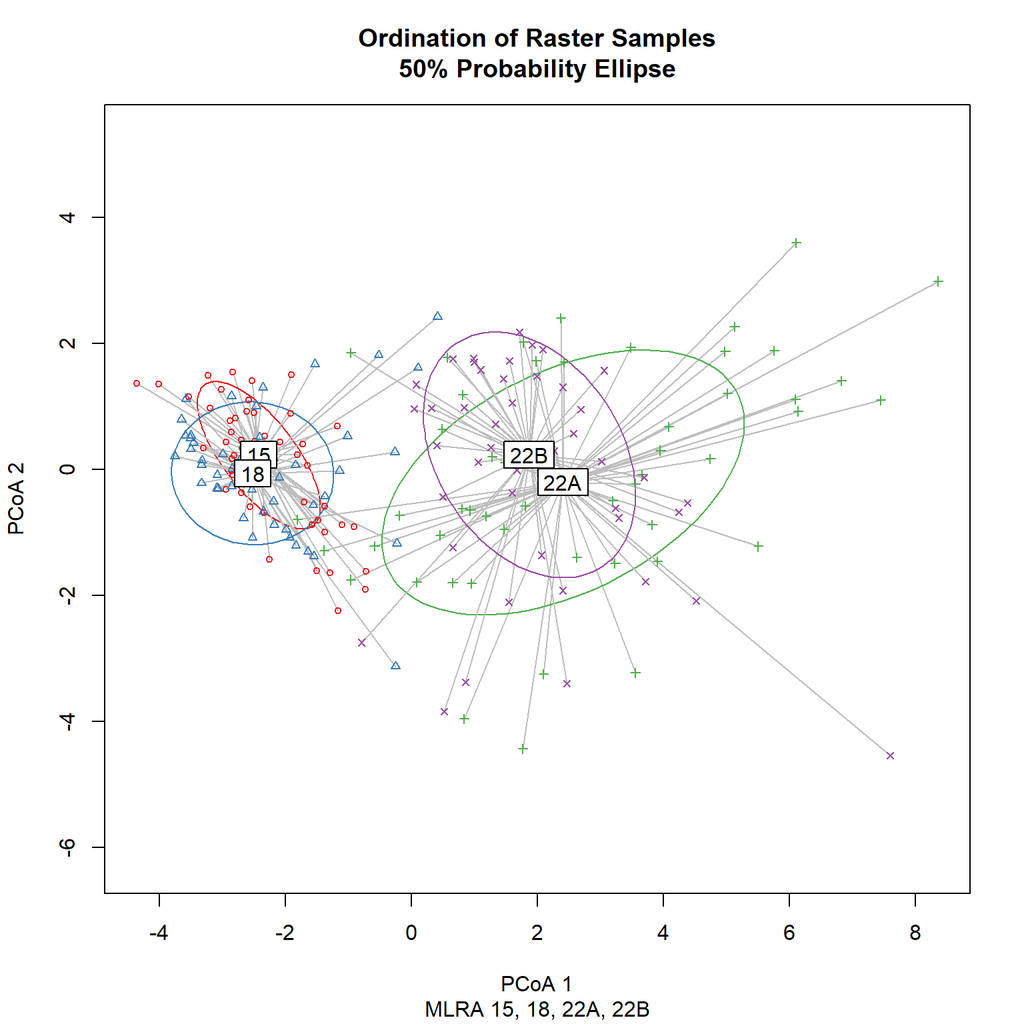

```r
## NOTE: data with very low variability will cause warnings
# eval numerical distance, removing first 3 columns of IDs
d.dist <- daisy(d.sub[, -c(1:3)], stand=TRUE)

## map distance matrix to 2D space via principal coordinates
d.betadisper <- betadisper(d.dist, group=d.sub$.id, bias.adjust = TRUE, sqrt.dist = FALSE, type='median')

## fancy plot
plot(
  d.betadisper, hull=FALSE, ellipse=TRUE, conf=0.5,
  col=cols, main='Ordination of Raster Samples\n50% Probability Ellipse', sub='MLRA 15, 18, 22A, 22B'
)
```

Pair-wise comparisons at the 90% level of confidence.

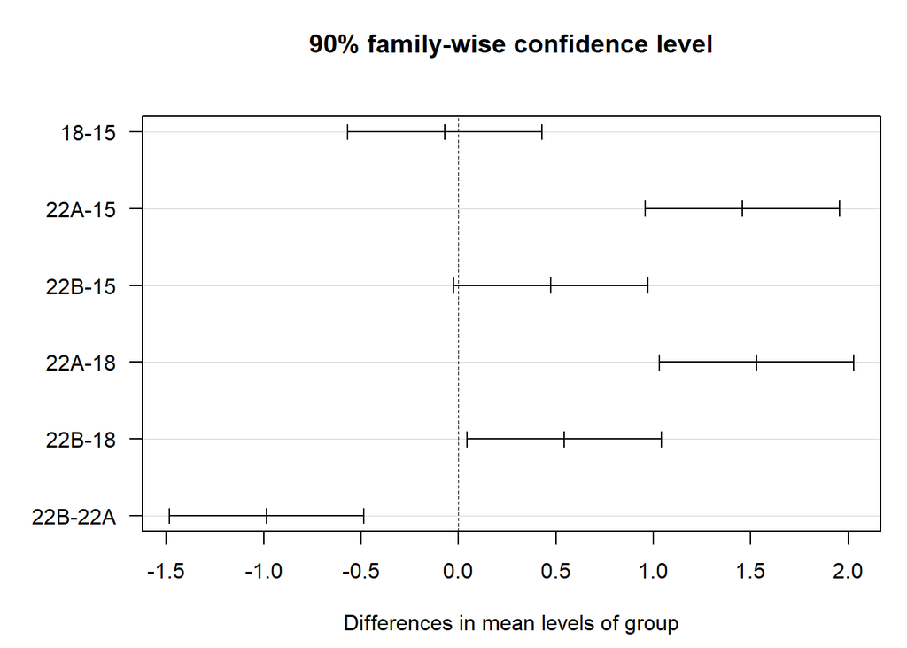

[output not shown]

```r
## pair-wise comparisons of variance
par(mar=c(4.5, 5.5, 4.5, 1))
plot(TukeyHSD(d.betadisper, conf.level = 0.9), las=1)
```

# References

Arkley, Rodney J. 1976. “Statistical Methods in Soil Classification Research.” In *Advances in Agronomy*, edited by N. C. Brady, 37–69. New York, NY: Academic Press.

Belbin, Lee, Daniel P. Faith, and Glenn W. Milligan. 1992. “A Comparison of Two Approaches to Beta-Flexible Clustering.” *Multivariate Behavioral Research* 27 (3): 417–33. https://doi.org/10.1207/s15327906mbr2703\_6.

Gower, J. C. 1971. “A General Coefficient of Similarity and Some of Its Properties.” *Biometrics* 27 (4): 857–71. http://www.jstor.org/stable/2528823.

Hole, F. D., and M. Hironaka. 1960. “An Experiment in Ordination of Some Soil Profiles.” *Proceedings of the Soil Science Society of America 24* 24: 309–12.

Kaufman, Leonard, and Peter J. Rousseeuw. 2005. *Finding Groups in Data an Introduction to Cluster Analysis*. Wiley-Interscience.

Legendre, P., and L. Legendre. 1998. *Numerical Ecology*. 2nd ed. Developments in Environmental Modeling 20. Amsterdam: Elsevier.

Rousseeuw, P. J. 1987. “Silhouettes: A Grapical Aid to the Interpretation and Validation of Cluster Analysis.” *Journal of Computational and Applied Mathmatics* 20: 53–65.

Sneath, Peter H. A., and Robert R. Sokal. 1973. *Numerical Taxonomy*. W.H. Freeman; Company.